# Standard Deviation

Bernard Ade

01-06-2017

Standard deviation is measure of spread. Standard deviation comes in handy when we are trying to study how much a data varies from the average. A low standard deviation indicates that the observed data is *closer* to the mean and a high deviation indicates data that is *farther* from the mean. With standard deviation we can answer questions such as:

- What percentage of men are taller than President Obama?
- Is a manufaturing process spiralling out of control?

##### Scenario

A hotel regional manager tracks check in-time for patrons in the lobby of 2 separate hotels. Although check-in time averages to about 30 mins for both hotels the standard deviation are signigicantly different. The standard deviation for hotel_1 is 8 and hotel_2 is 14. Therefore, on average the patron check-in time deviates from the mean at about 8 and 14 mins respectively. Lets take a look at a plot that illustrates this concept visually.

```r
hotel_1  = rnorm(50, 30, 8)
hotel_2  = rnorm(50, 30, 14)
par(mfrow=c(2,1))
barplot(hotel_1)
abline(h=mean(hotel_2),col = 'red')
```

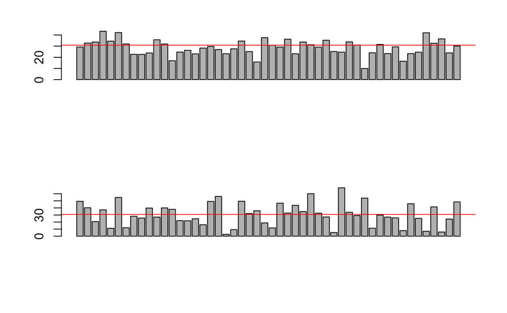

```r
barplot(hotel_2)
abline(h=mean(hotel_2),col = 'red')
```

Our plot shows the distance of each bar from the mean indicated by the red line. Although the mean is the same in both groups, *Hotel_1* varies a little and *Hotel_2* height varies a lot.

Here are some more resources on standard deviation.

[Statistics: Standard deviation | Descriptive statistics | Probability and Statistics | Khan Academy](https://www.youtube.com/watch?v=HvDqbzu0i0E)

[Social Statistics - Variability: Variance + Standard Deviation](https://www.youtube.com/watch?v=gKk-MJew7ew)